# HW3

# Part A. Graphic Summaries

```r
data("Weekly")
summary(Weekly)
```

```
##       Year           Lag1               Lag2               Lag3
##  Min.   :1990   Min.   :-18.1950   Min.   :-18.1950   Min.   :-18.1950
##  1st Qu.:1995   1st Qu.: -1.1540   1st Qu.: -1.1540   1st Qu.: -1.1580
##  Median :2000   Median :  0.2410   Median :  0.2410   Median :  0.2410
##  Mean   :2000   Mean   :  0.1506   Mean   :  0.1511   Mean   :  0.1472
##  3rd Qu.:2005   3rd Qu.:  1.4050   3rd Qu.:  1.4090   3rd Qu.:  1.4090
##  Max.   :2010   Max.   : 12.0260   Max.   : 12.0260   Max.   : 12.0260
##       Lag4               Lag5              Volume            Today
##  Min.   :-18.1950   Min.   :-18.1950   Min.   :0.08747   Min.   :-18.1950
##  1st Qu.: -1.1580   1st Qu.: -1.1660   1st Qu.:0.33202   1st Qu.: -1.1540
##  Median :  0.2380   Median :  0.2340   Median :1.00268   Median :  0.2410
##  Mean   :  0.1458   Mean   :  0.1399   Mean   :1.57462   Mean   :  0.1499
##  3rd Qu.:  1.4090   3rd Qu.:  1.4050   3rd Qu.:2.05373   3rd Qu.:  1.4050
##  Max.   : 12.0260   Max.   : 12.0260   Max.   :9.32821   Max.   : 12.0260
##  Direction
##  Down:484
##  Up  :605
##
##
##
##
```

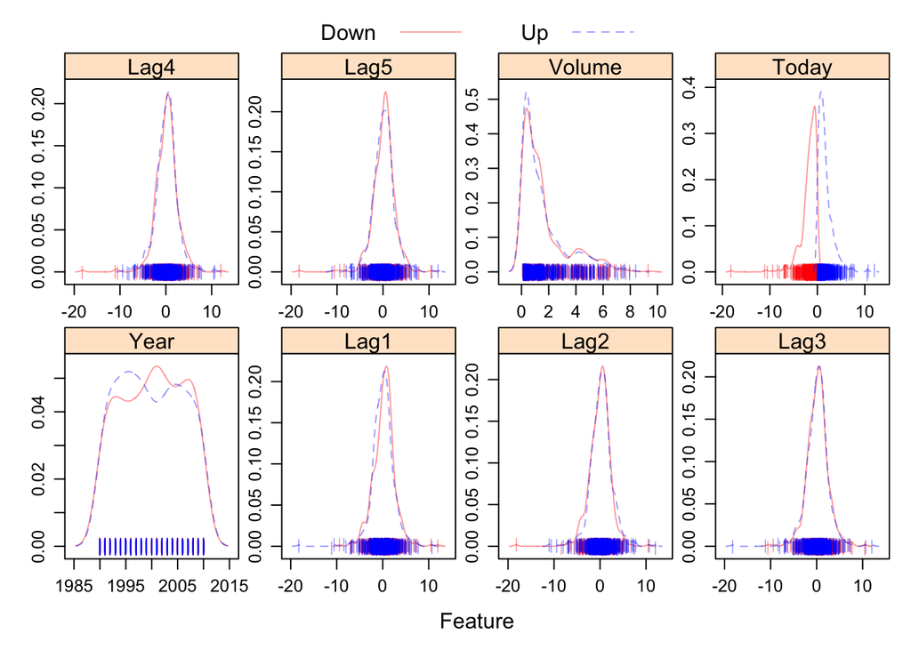

```r
transparentTheme(trans = .4)
featurePlot(x = Weekly[, 1:8],
            y = Weekly$Direction,
            scales = list(x = list(relation = "free"),
                          y = list(relation = "free")),
            plot = "density", pch = "|",
            auto.key = list(columns = 2)) # density plot
```

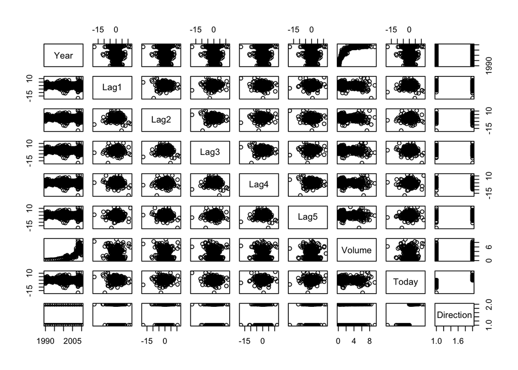

```r
pairs(Weekly) # pairs scatterplot
```

# Part B.

```r
train = Weekly %>%
  filter(Year <= 2008)
test = Weekly %>%
  filter(Year > 2008)
glm_fit = glm(Direction ~ Lag1 + Lag2 + Lag3 + Lag4 + Lag5 + Volume,
              data = train,
              family = binomial)
summary(glm_fit)
```

```
##
## Call:
## glm(formula = Direction ~ Lag1 + Lag2 + Lag3 + Lag4 + Lag5 +
##     Volume, family = binomial, data = train)
##
## Deviance Residuals:
##     Min       1Q   Median       3Q      Max
## -1.7186  -1.2498   0.9823   1.0841   1.4911
##
## Coefficients:
##             Estimate Std. Error z value Pr(>|z|)
## (Intercept)  0.33258    0.09421   3.530 0.000415 ***
## Lag1        -0.06231    0.02935  -2.123 0.033762 *
## Lag2         0.04468    0.02982   1.499 0.134002
## Lag3        -0.01546    0.02948  -0.524 0.599933
## Lag4        -0.03111    0.02924  -1.064 0.287241
## Lag5        -0.03775    0.02924  -1.291 0.196774
## Volume      -0.08972    0.05410  -1.658 0.097240 .
## ---
## Signif. codes:  0 '***' 0.001 '**' 0.01 '*' 0.05 '.' 0.1 ' ' 1
##
## (Dispersion parameter for binomial family taken to be 1)
##
##     Null deviance: 1354.7  on 984  degrees of freedom
## Residual deviance: 1342.3  on 978  degrees of freedom
## AIC: 1356.3
##
## Number of Fisher Scoring iterations: 4
```

From performing logistic regression on the training data, it is found that ‘Lag1’ is a significant predictor due to its p-value < 0.05.

```r
# Confusion Matrix
prob = predict(glm_fit, newdata = test, type = "response")
pred = rep("Down", length(prob))
pred[prob > 0.5] = "Up"
confusionMatrix(data = as.factor(pred), reference = test$Direction, positive = "Up")
```

```
## Confusion Matrix and Statistics
##
##           Reference
## Prediction Down Up
##       Down   31 44
##       Up     12 17
##
##                Accuracy : 0.4615
##                  95% CI : (0.3633, 0.562)
##     No Information Rate : 0.5865
##     P-Value [Acc > NIR] : 0.9962
##
##                   Kappa : -3e-04
##
##  Mcnemar's Test P-Value : 3.435e-05
##
##             Sensitivity : 0.2787
##             Specificity : 0.7209
##          Pos Pred Value : 0.5862
##          Neg Pred Value : 0.4133
##              Prevalence : 0.5865
##          Detection Rate : 0.1635
##    Detection Prevalence : 0.2788
##       Balanced Accuracy : 0.4998
##
##        'Positive' Class : Up
##
```

- From the confusion matrix, the overall fraction of correct predictions using the testing data is 0.4615, 95% CI (0.3633, 0.562).
- P-value = 0.9962 > 0.05, indicating we fail to reject the null hypothesis and accuracy = NIR(NIR = 0.5865). (max((True Positive + False Positive)/n, (False Negative + True Negative)/n))
- Kappa = -3*10^-4, indicating the model doesn’t fit the data well. Kappa closer to 1, better the model fits.
- Sensitivity = 0.2787 [True Positive/(True Positive + False Negative)], 27.87% of true positives are correctly identified.
- Specificity = 0.7209 [True Negative/(True Negative + False Positive)], 72.09% of true negatives are correctly identified.

# Part C.

```r
glm_fit2 = glm(Direction ~ Lag1 + Lag2, data = train, family = binomial)
summary(glm_fit2)
```

```
##
## Call:
## glm(formula = Direction ~ Lag1 + Lag2, family = binomial, data = train)
##
## Deviance Residuals:
##     Min       1Q   Median       3Q      Max
## -1.6149  -1.2565   0.9989   1.0875   1.5330
##
## Coefficients:
##             Estimate Std. Error z value Pr(>|z|)
## (Intercept)  0.21109    0.06456   3.269  0.00108 **
## Lag1        -0.05421    0.02886  -1.878  0.06034 .
## Lag2         0.05384    0.02905   1.854  0.06379 .
## ---
## Signif. codes:  0 '***' 0.001 '**' 0.01 '*' 0.05 '.' 0.1 ' ' 1
##
## (Dispersion parameter for binomial family taken to be 1)
##
##     Null deviance: 1354.7  on 984  degrees of freedom
## Residual deviance: 1347.0  on 982  degrees of freedom
## AIC: 1353
##
## Number of Fisher Scoring iterations: 4
```

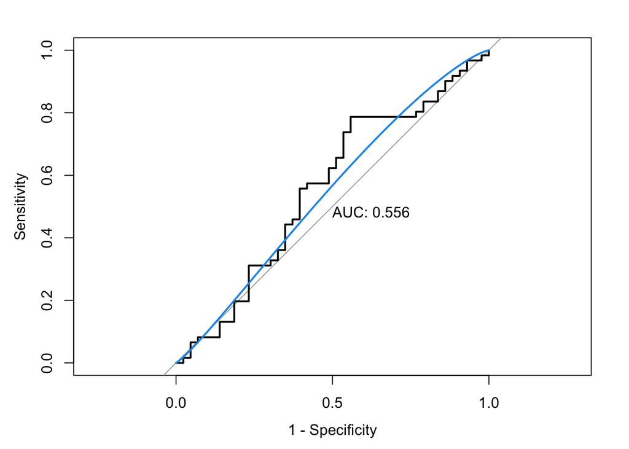

```r
###Plot the ROC curve using the test data and report the AUC
glm2_prob = predict(glm_fit2, newdata = test, type = "response")
roc = roc(test$Direction, glm2_prob)
plot(roc, legacy.axes = TRUE, print.auc = TRUE)
plot(smooth(roc), col = 4, add = TRUE)
```

From the ROC curve, AUC = 0.556.

# Part D.

## LDA

```r
lda_fit = lda(Direction ~ Lag1 + Lag2, data = train)
lda_pred = predict(lda_fit, newdata = test)
roc_lda = roc(test$Direction, lda_pred$posterior[,2], levels = c("Down", "Up"))
```

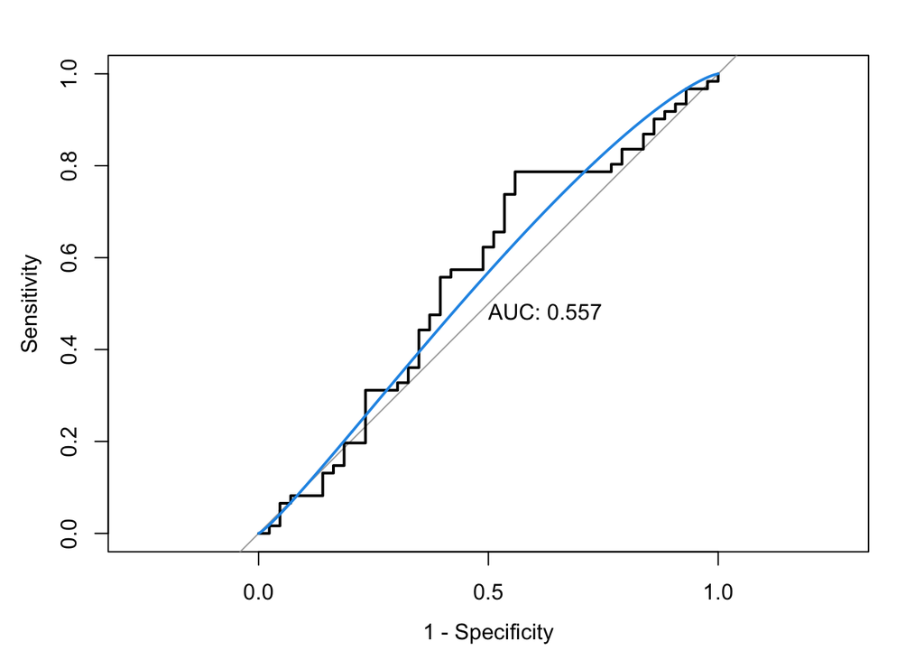

```r
plot(roc_lda, legacy.axes = TRUE, print.auc = TRUE)
plot(smooth(roc_lda), col = 4, add = TRUE)
```

LDA AUC = 0.557.

## QDA

```r
qda_fit = qda(Direction ~ Lag1 + Lag2, data = train)
qda_pred = predict(qda_fit, newdata = test)
roc_qda = roc(test$Direction, qda_pred$posterior[,2], levels = c("Down", "Up"))
```

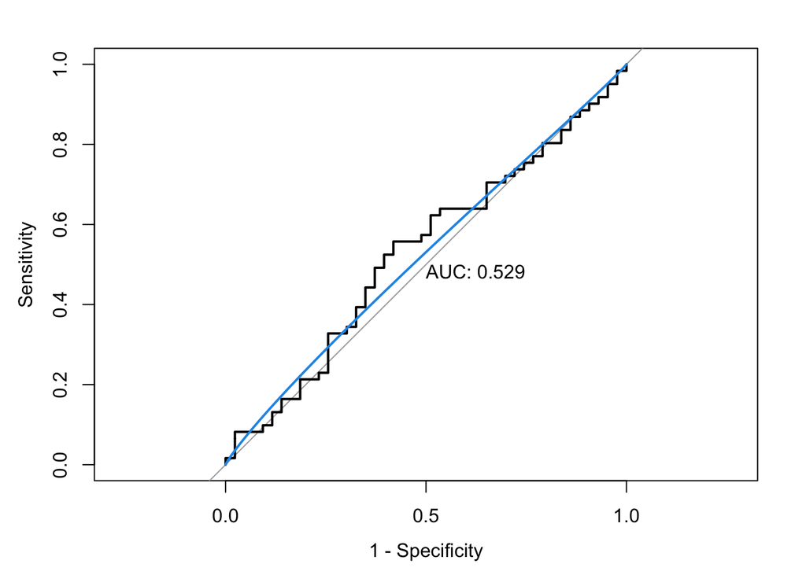

```r
plot(roc_qda, legacy.axes = TRUE, print.auc = TRUE)
plot(smooth(roc_qda), col = 4, add = TRUE)
```

```r
###AUC is 0.529
```

QDA AUC = 0.529.

# Part E.

```r
set.seed(1)
ctrl = trainControl(method = "repeatedcv",
                    repeats = 5,
                    summaryFunction = twoClassSummary,
                    classProbs = TRUE)
fit_knn <- train(x = train[2:3],
                 y = train$Direction,
                 method = "knn",
                 preProcess = c("center", "scale"),
                 tuneGrid = data.frame(k = seq(1, 200, by = 5)),
                 trControl = ctrl)
summary(fit_knn)
```

```
##             Length Class      Mode
## learn       2      -none-     list
## k           1      -none-     numeric
## theDots     0      -none-     list
## xNames      2      -none-     character
## problemType 1      -none-     character
## tuneValue   1      data.frame list
## obsLevels   2      -none-     character
## param       0      -none-     list
```

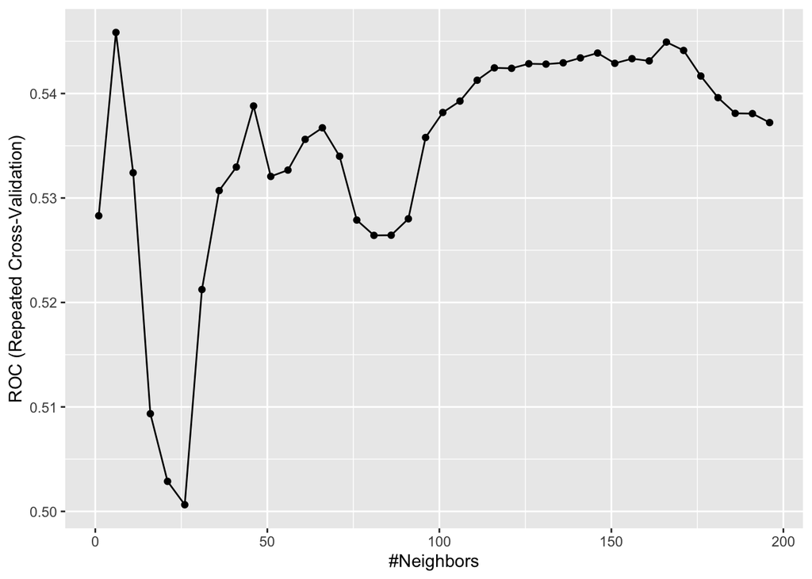

```r
ggplot(fit_knn)
```

```r
fit_knn$bestTune
```

```
##   k
## 2 6
```

```r
knn_pred =  predict(fit_knn, newdata = test , type = "prob")
roc_knn = roc(test$Direction, knn_pred$Down, levels = c("Down", "Up"))
```

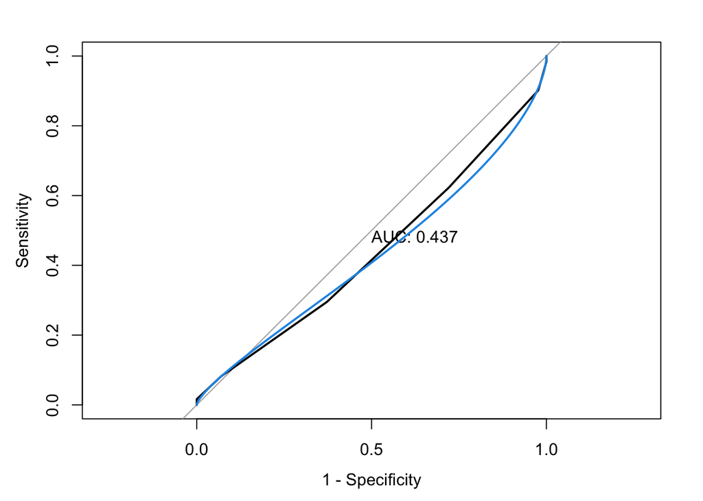

```r
plot(roc_knn, legacy.axes = TRUE, print.auc = TRUE)
plot(smooth(roc_knn), col = 4, add = TRUE)
```

The KNN AUC = 0.437. Comparing with GLM, LDA, QDA and KNN, LDA has the largest AUC, indicating LDA predicts the data best. Due to its high error, further investigation on better models is required.